# Question

In Adams, Massachusetts, 5 candidates (V through Z) are running in an election with a single winner. There are 9 voters (A through I) who each rank the candidates from 1 to 5, with 1 meaning first choice and 5 meaning last choice. Those rankings are shown below. Each column represents a single voter’s ranking.

|  | voter A | voter B | voter C | voter D | voter E | voter F | voter G | voter H | voter I |
| --- | --- | --- | --- | --- | --- | --- | --- | --- | --- |
| candidate V | 5 | 3 | 4 | 4 | 4 | 2 | 2 | 5 | 5 |
| candidate W | 2 | 2 | 5 | 3 | 1 | 3 | 5 | 1 | 1 |
| candidate X | 1 | 1 | 3 | 5 | 3 | 5 | 4 | 2 | 4 |
| candidate Y | 3 | 5 | 1 | 1 | 2 | 1 | 3 | 3 | 3 |
| candidate Z | 4 | 4 | 2 | 2 | 5 | 4 | 1 | 4 | 2 |

What [Borda count](https://en.wikipedia.org/wiki/Borda_count) would each candidate get?

- Borda count of candidate V: ##ANSWER1##
- Borda count of candidate W: ##ANSWER2##
- Borda count of candidate X: ##ANSWER3##
- Borda count of candidate Y: ##ANSWER4##
- Borda count of candidate Z: ##ANSWER5##
- Who wins the Borda election? ##ANSWER6##

## Answerlist

- 11
- 12
- 13
- 15
- 16
- 17
- 21
- 22
- 23
- 25
- 11
- 12
- 13
- 15
- 16
- 17
- 21
- 22
- 23
- 25
- 11
- 12
- 13
- 15
- 16
- 17
- 21
- 22
- 23
- 25
- 11
- 12
- 13
- 15
- 16
- 17
- 21
- 22
- 23
- 25
- 11
- 12
- 13
- 15
- 16
- 17
- 21
- 22
- 23
- 25
- Candidate V
- Candidate W
- Candidate X
- Candidate Y
- Candidate Z

# Solution

There are 5 candidates. So, we subtract each preference number from 5 to get Borda points. We then add all the Borda points from each voter.

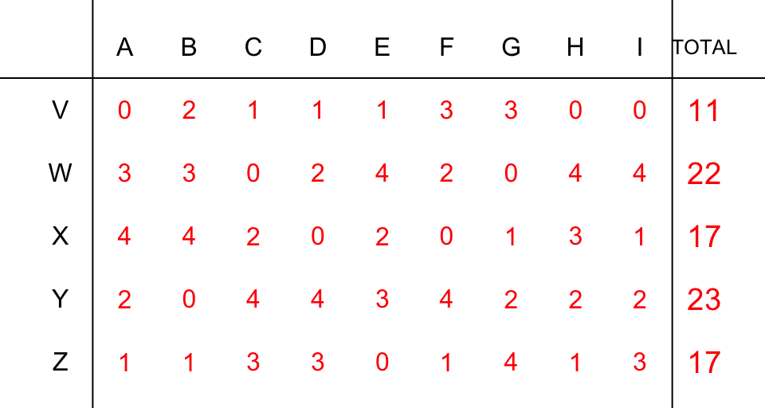

# Meta-information

extype: cloze exclozetype: schoice|schoice|schoice|schoice|schoice|schoice exsolution: 1000000000|0000000100|0000010000|0000000010|0000010000|00010 exname: borda